# stoch_bd_SIR_POMP

Alexandra Souly

02/07/2020

## R Markdown

I used POMP to create a deteministic and a stochastic version of the basic SIR model. I am using the discrete difference equations version for both. I tried adding in simple birth-death dynamics too.

POMP stores all data in its own pomp class that can be used for complicated methods in the package, so I hope it will be easier to implement algorithms later within the package.

We start by specifying the deterministic model skeleton, I use the following equations:  
(“D” signifies the update value for the map in the equations)

```r
# deterministic skeleton
skel <- Csnippet("
  DS = S - Beta*S*I/N           + b*N - d*S ;
  DI = I + Beta*S*I/N - gamma*I       - d*I;
  DR = R              + gamma*I       - d*R;
")
```

Then I specify the stochastic stepping process:  
I used 1-exp(r) for the per capita stepping probabilities for rate r in the difference eqs and a binomial distribution for the numbers of individuals moving between compartments.

```r
# stochastic stepping process

stochStep <- Csnippet("
  p_SI = 1 - exp(-Beta*I/N);
  p_IR = 1 - exp(-gamma);
  p_b  = 1 - exp(-b);
  p_d  = 1 - exp(-d);

  n_SI = rbinom(S,p_SI);
  n_IR = rbinom(I,p_IR);

  b_N  = rbinom(N, p_b);
  d_I  = rbinom(I, p_d);
  d_R  = rbinom(R, p_d);
  d_S  = rbinom(S, p_d);

  S = S - n_SI        + b_N  - d_S;
  I = I + n_SI - n_IR        - d_I;
  R = R        + n_IR        - d_R;

")
```

I set some arbitrary initial states and parameters (one infected out of 763, I think something like measles has parameters like that? )

```r
# initial values of states
init1 <- Csnippet("
  S = N-1;
  I = 1;
  R = 0;
  ")

params1 <- c(Beta=1, gamma = 1/13, N= 763, b=0.05, d = 0.05)
```

Then we can create a POMP object:  
We follow the process for 50 days, POMP will use our stochastic process described above.

```r
closed_sir <- pomp(data=data.frame(time=1:50,data=NA),
                   times="time",
                   t0=0,
                   rprocess=discrete_time(step.fun=stochStep,delta.t=1),
                   skeleton = map(skel),
                   rinit=init1,
                   statenames=c("S","I","R", "p_SI", "p_IR", "p_b", "p_d", "n_SI", "n_IR", "b_N", "d_I", "d_S", "d_R"),
                   paramnames=c("Beta","gamma","N", "b", "d"))
```

```r
sim <- simulate(closed_sir,params=params1,format = "data.frame", nsim = 100)
head(sim, 3)
```

```
##   time .id   S I R        p_SI       p_IR        p_b        p_d n_SI n_IR b_N
## 1    1   1 758 3 0 0.001309758 0.07403892 0.04877058 0.04877058    2    0  39
## 2    1   2 765 1 0 0.001309758 0.07403892 0.04877058 0.04877058    0    0  36
## 3    1   3 750 1 0 0.001309758 0.07403892 0.04877058 0.04877058    0    0  35
##   d_I d_S d_R data
## 1   0  41   0   NA
## 2   0  33   0   NA
## 3   0  47   0   NA
```

```r
tail(sim, 3)
```

```
##      time .id   S   I   R      p_SI       p_IR        p_b        p_d n_SI n_IR
## 4998   50  98 109 254 450 0.2887705 0.07403892 0.04877058 0.04877058   33   25
## 4999   50  99 112 287 428 0.3017016 0.07403892 0.04877058 0.04877058   49   20
## 5000   50 100 104 272 375 0.2924894 0.07403892 0.04877058 0.04877058   45   19
##      b_N d_I d_S d_R data
## 4998  34  14   5  20   NA
## 4999  40  16   7  17   NA
## 5000  42  18   5  18   NA
```

```r
traj <- trajectory(closed_sir,params=params1,format="data.frame")
head(traj, 3)
```

```
##          S        I          R p_SI p_IR p_b p_d n_SI n_IR b_N d_I d_S d_R time
## 1 761.0513 1.871766 0.07692308   NA   NA  NA  NA   NA   NA  NA  NA  NA  NA    1
## 2 759.2818 3.501182 0.21705895   NA   NA  NA  NA   NA   NA  NA  NA  NA  NA    2
## 3 755.9836 6.540921 0.47552768   NA   NA  NA  NA   NA   NA  NA  NA  NA  NA    3
##   .id
## 1   1
## 2   1
## 3   1
```

```r
tail(traj,3)
```

```
##           S        I        R p_SI p_IR p_b p_d n_SI n_IR b_N d_I d_S d_R time
## 48 96.50406 262.8747 403.6213   NA   NA  NA  NA   NA   NA  NA  NA  NA  NA   48
## 49 96.58053 262.7581 403.6614   NA   NA  NA  NA   NA   NA  NA  NA  NA  NA   49
## 50 96.64159 262.6680 403.6904   NA   NA  NA  NA   NA   NA  NA  NA  NA  NA   50
##    .id
## 48   1
## 49   1
## 50   1
```

We then plot to see how the stochastic results differ from the deterministic trajectory (in black):

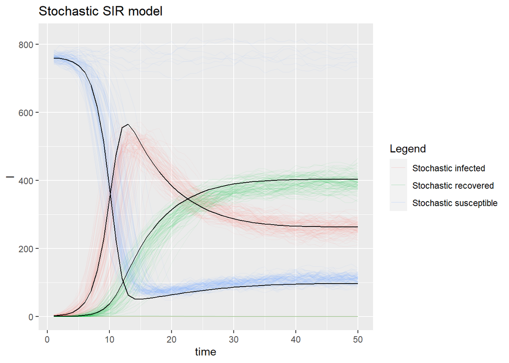